# Gulf of Maine Seasonal Sea Surface Temperature Update

Seasonal Patterns in Sea Surface Temperatures

Author

Adam Kemberling

Published

September 6, 2022

# About the Updates:

Over the past decade, scientists at [the Gulf of Maine Research Institute](https://www.gmri.org) have led a body of research that highlights the rapid pace of warming in the Gulf of Maine. To keep you informed, we share seasonal updates about conditions in the Gulf of Maine.

**Note About the Data:** The figures in this report are creating using remotely-sensed satellite data as part of publicly funded research efforts. Satellite SST data was obtained from NOAA’s National Center for Environmental Information (NCEI), with all maps and figures displaying [NOAA’s Optimum Interpolation Sea Surface Temperature Data](https://www.ncei.noaa.gov/products/optimum-interpolation-sst).

**Note on Preliminary Data:** This dataset has a 2-week latency period, during which values may change due to quality control measures. Any data within 14 days of the publishing date may be subject to change.

# The Gulf of Maine Region

For analyses like these, it is important to be clear about the spatial extent that “defines” the Gulf of Maine (Figure 1), as different borders could produce different numbers. The spatial extent we use as the “Gulf of Maine” is displayed below. This area is consistent with previous reports and publications GMRI has produced.

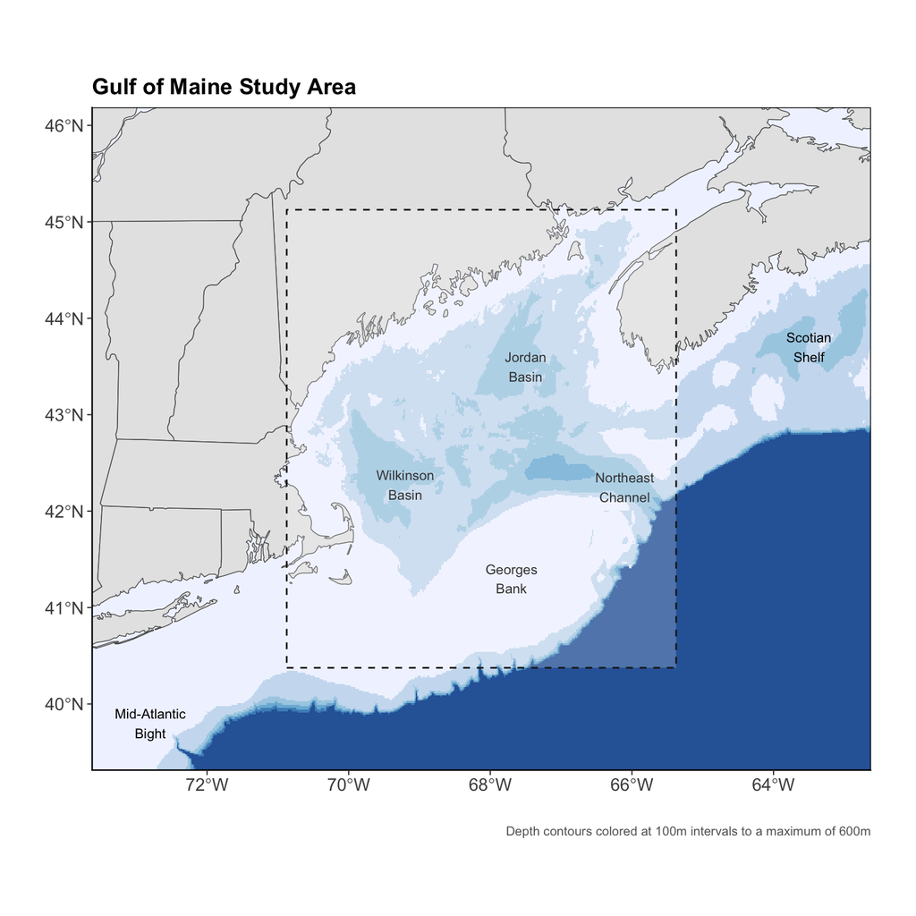

For this seasonal report, we present an analysis of SST for Summer (June 1st - August 31st).

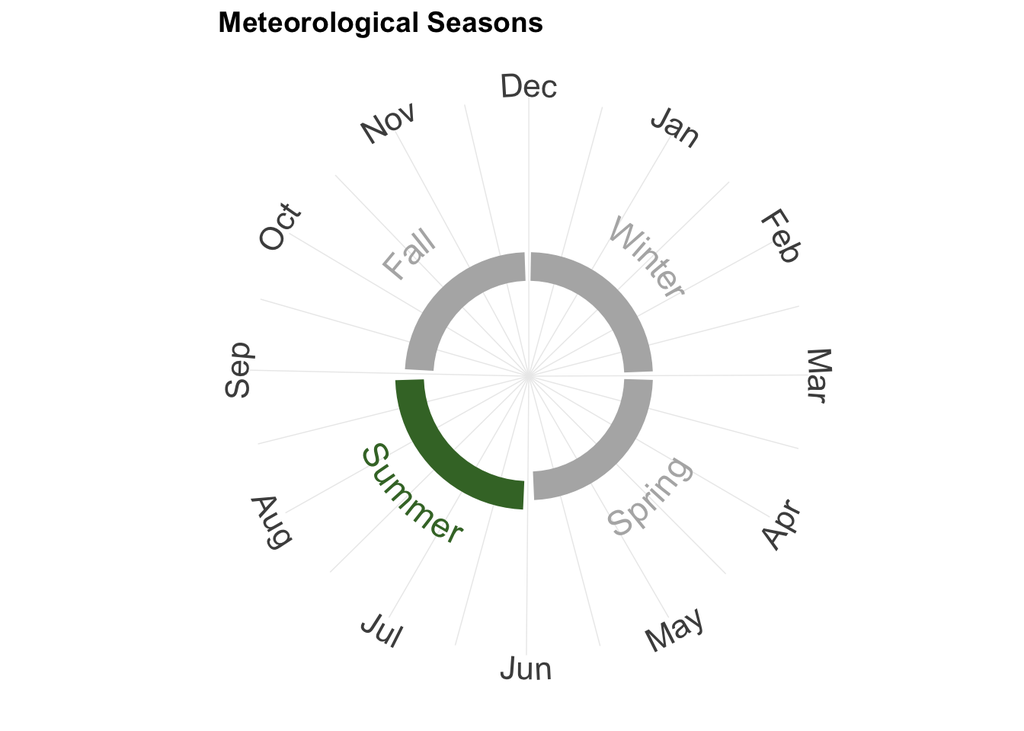

## Highlights

It was the 3rd hottest summer on record for the period of 1982-2022.

## Weekly Temperatures

In the below table, we highlight how the SST for each week this summer compares to a 30-year baseline period (climatological averages from 1982 through 2011).

The observed SST, long-term average SST, as well as departures from the long-term average (SST anomalies) are shown.

**Weekly Sea Surface Temperatures - Summer**

Summer (June 1st - August 31st)

| *One-Week Period* | *Observed Temperature* °F | *Observed Temperature* °C | *Climatological Average* °F | *Climatological Average* °C | *Temperature Anomaly* °F | *Temperature Anomaly* °C |
| --- | --- | --- | --- | --- | --- | --- |
| Jun 01 - Jun 04 | 53.5 | 12.0 | 49.6 | 9.78 | 3.92 | 2.18 |
| Jun 05 - Jun 11 | 55.5 | 13.1 | 50.9 | 10.50 | 4.61 | 2.56 |
| Jun 12 - Jun 18 | 57.4 | 14.1 | 52.7 | 11.50 | 4.78 | 2.66 |
| Jun 19 - Jun 25 | 56.6 | 13.7 | 54.4 | 12.50 | 2.21 | 1.23 |
| Jun 26 - Jul 02 | 59.3 | 15.1 | 56.2 | 13.40 | 3.09 | 1.72 |
| Jul 03 - Jul 09 | 61.2 | 16.2 | 57.8 | 14.30 | 3.43 | 1.90 |
| Jul 10 - Jul 16 | 62.6 | 17.0 | 59.2 | 15.10 | 3.38 | 1.88 |
| Jul 17 - Jul 23 | 63.6 | 17.6 | 60.3 | 15.70 | 3.26 | 1.81 |
| Jul 24 - Jul 30 | 64.8 | 18.2 | 61.3 | 16.30 | 3.47 | 1.93 |
| Jul 31 - Aug 06 | 66.5 | 19.2 | 62.0 | 16.70 | 4.53 | 2.52 |
| Aug 07 - Aug 13 | 67.7 | 19.8 | 62.4 | 16.90 | 5.27 | 2.93 |
| Aug 14 - Aug 20 | 65.6 | 18.7 | 62.5 | 16.90 | 3.12 | 1.74 |
| Aug 21 - Aug 27 | 67.2 | 19.6 | 62.2 | 16.80 | 4.99 | 2.77 |
| Aug 28 - Aug 31 | 67.2 | 19.5 | 61.9 | 16.60 | 5.28 | 2.93 |

*Data Source: NOAA OISSTv2 Daily Sea Surface Temperature Data.*  
*Climatology Reference Period: 1982-2011.*

## Monthly Statistics

| *Month* | *Observed Temperature* °F | *Observed Temperature* °C | *Climatological Average* °F | *Climatological Average* °C | *Temperature Anomaly* °F | *Temperature Anomaly* °C | *Temperature Progression* High/Low °F |
| --- | --- | --- | --- | --- | --- | --- | --- |
| Jun | 56.5 | 13.6 | 52.8 | 11.6 | 3.75 | 2.08 |  |
| Jul | 62.9 | 17.2 | 59.5 | 15.3 | 3.36 | 1.87 |  |
| Aug | 66.9 | 19.4 | 62.2 | 16.8 | 4.62 | 2.57 |  |

*Data Source: NOAA OISSTv2 Daily Sea Surface Temperature Data.*  
*Climatology Reference Period: 1982-2011.*

## Seasonal Trends and Anomalies in Context

The Gulf of Maine is an area of particular interest to the scientific community because of the remarkable rate of warming it has experienced in recent years.

When looking at average summer temperatures, there is a clear long-term increase, with SST’s warming at a rate of 1.06°F per decade. A major factor driving this trend is a shift in the thermal regime that we began to observe around 2010.

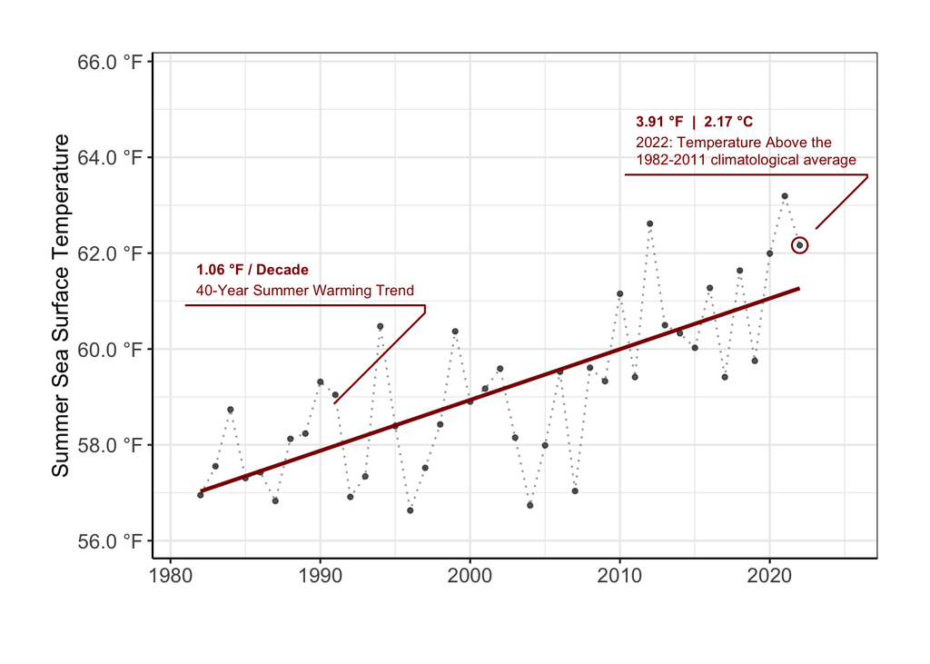

This period of faster warming is part of what appears to be a distinct regime in the Gulf of Maine. The drivers of this (e.g., a weakening of the Atlantic Meridional Overturning Circulation and shifts in the path of the Gulf Stream) have been [well-documented in the peer-reviewed literature](https://eos.org/features/why-is-the-gulf-of-maine-warming-faster-than-99-of-the-ocean), including through research by GMRI scientists.

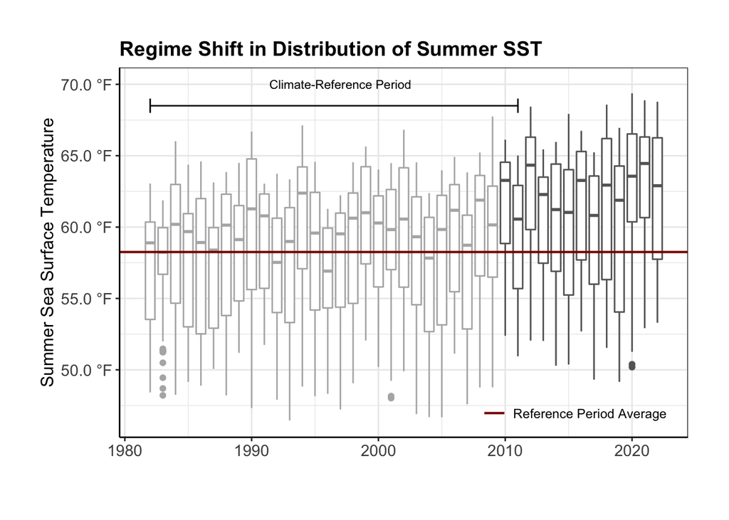

## How Does 2022 Compare?

2022 is among the warmest summers seen in the Gulf of Maine during this 40+ year period. When compared against all previous summers for which we have reliable satellite data (i.e., back to 1982), this year ranks **3rd** among the hottest on record.

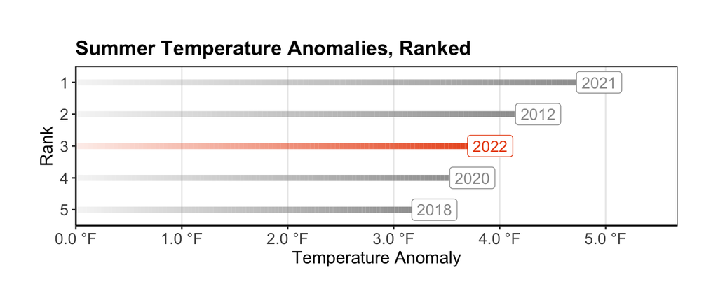

## Marine Heatwave Timeline

The most commonly used definition of a [“marine heatwave” (MHW)](http://www.marineheatwaves.org/all-about-mhws.html) is when daily average SSTs exceed the 90th percentile of a climatological (i.e., 30-year) average for at least 5 consecutive days. Successive heatwave gaps of 2 days or less are considered part of the same event.

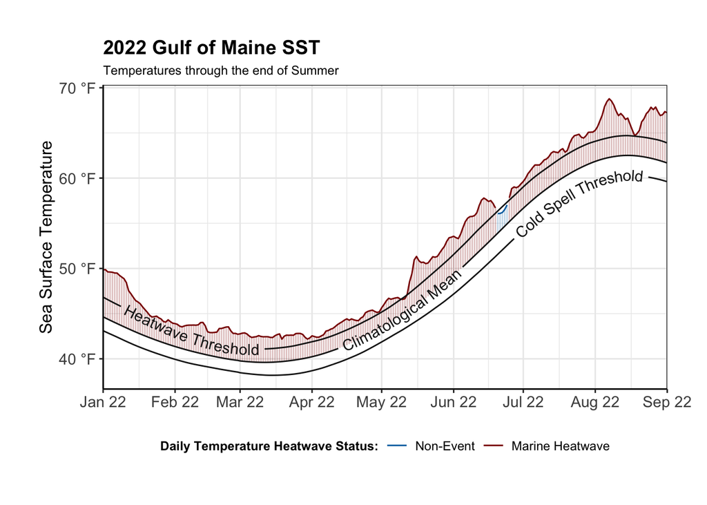

## Heatwave Anomaly Timeline

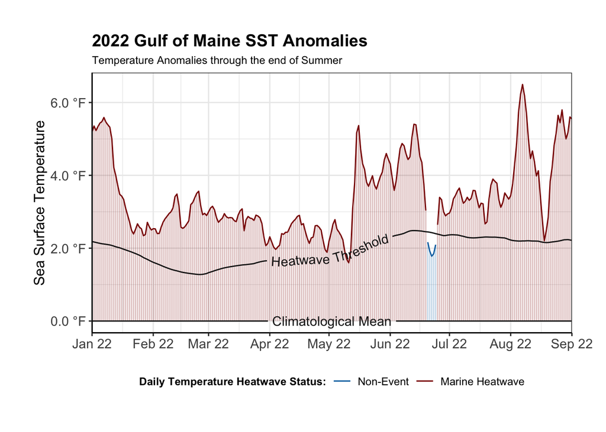

## Heatmap of Temperature Anomalies and Heatwave Events

Looking at the full record of daily SST anomalies in the Gulf of Maine (figure below), the distinct thermal regime shift beginning around 2010 is evident. Indeed, since 2012, the Gulf of Maine has experienced far more persistent MHW conditions (indicated by solid black lines) than at any other point in the satellite record.

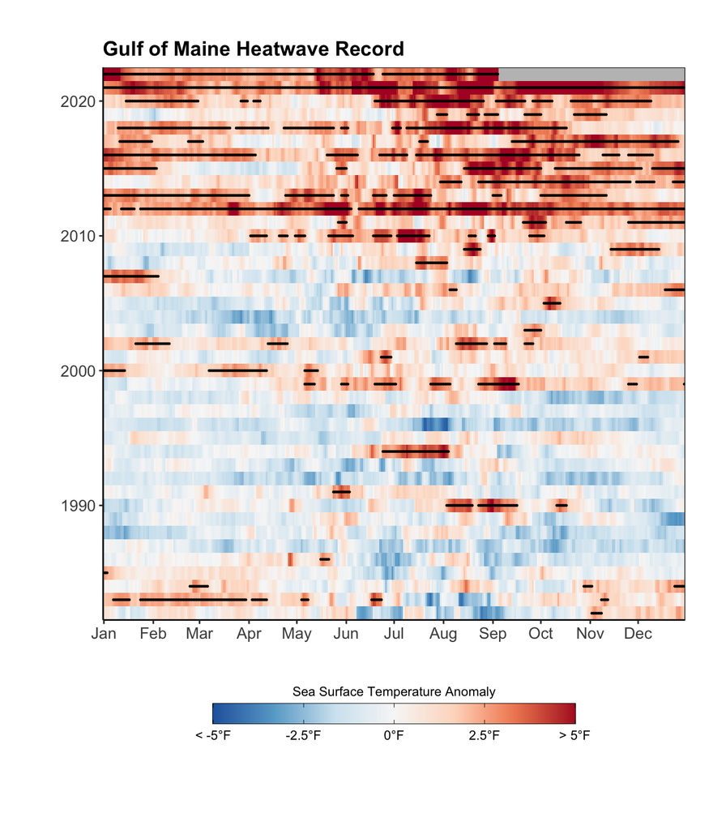

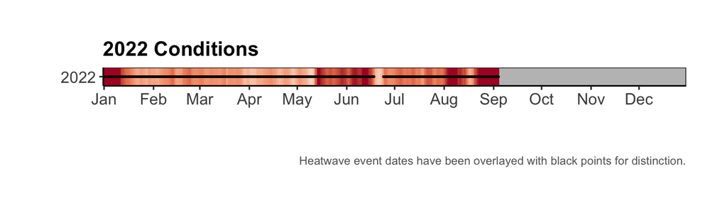

## Longest Heatwave on Record

The heatwave event of 2022 was actually a continuation of an historical event, the longest heatwave in the region’s history.

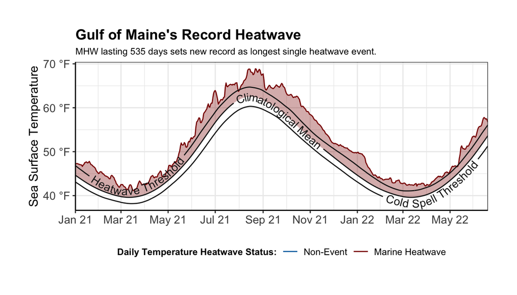

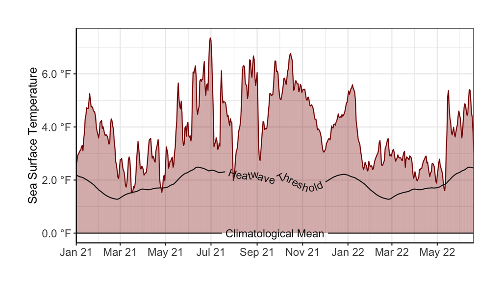

The full heatwave event lasted a total of 535, and during that period temperatures were on average 3.87°F what they were compared to the climate reference period.

## Spatial Distribution of Seasonal Anomalies

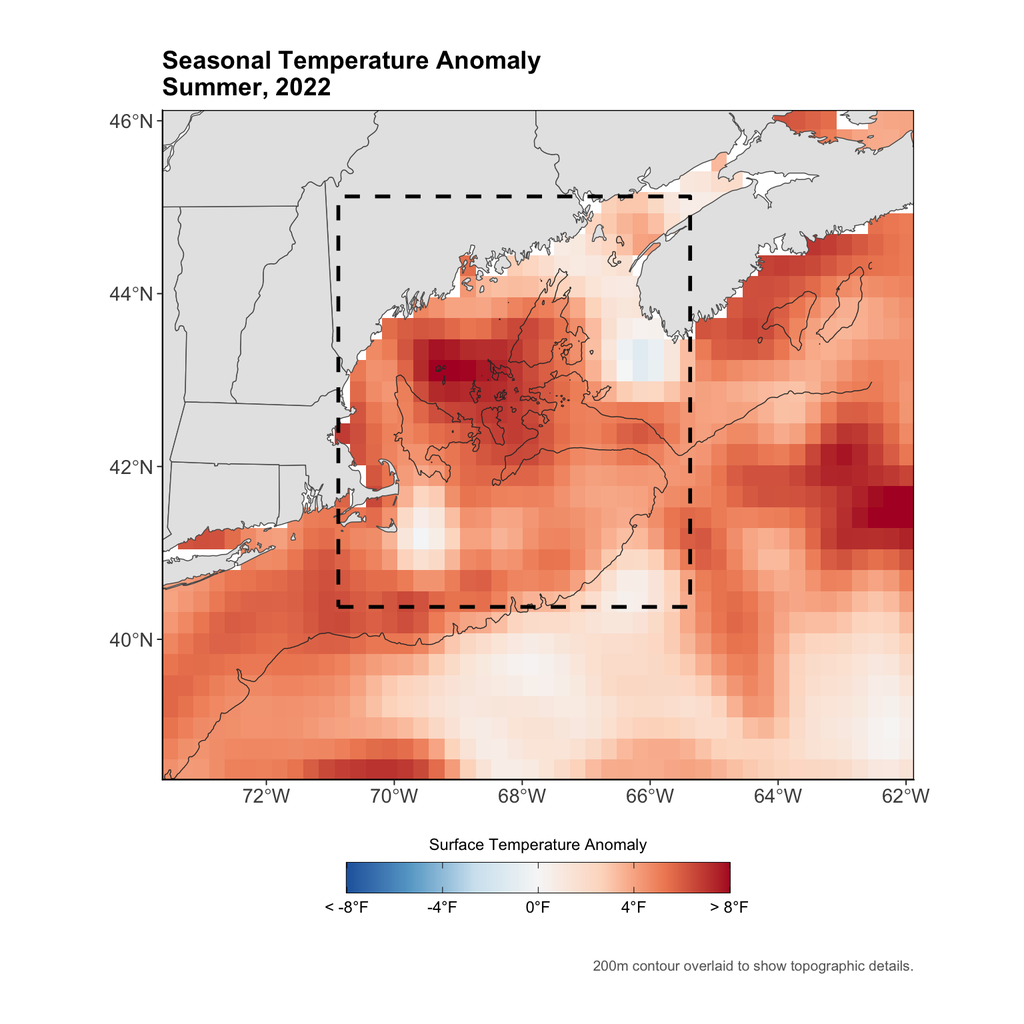

## Monthly Temperature Anomalies

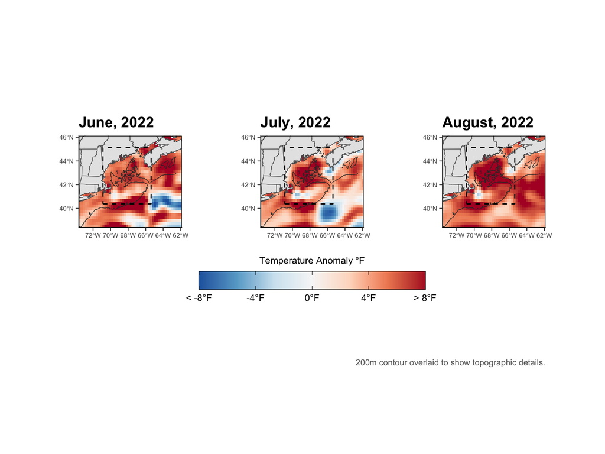

A work by [Adam A. Kemberling](https://github.com/adamkemberling/)

*Akemberling@gmri.org*